# Analyze Data

David Lukacsovich

2022-05-06

# 1. Get Data

First, we need to get the cleaned data, and modules that we will be working with

## Load Libraries

```r
suppressMessages({
  library(dplyr)
  library(tidyr)
  library(lubridate)
  library(stringr)
  library(ggplot2)
})
```

## Read Data

Next, we read in our data

```r
read_dir <- 'Read Data/Monthly_Cleaned'
file_names <- list.files(path=read_dir, pattern='\\.csv$')
read_names <- paste(read_dir, file_names, sep='/')

colClasses <- c('factor', 'factor', 'character', 'numeric',
                'character', 'character', 'character', 'character')
df <- read.csv(read_names[1], colClasses=colClasses)

for (read_name in read_names[2:length(read_names)]){
  df <- rbind(df, read.csv(read_name, colClasses=colClasses))
}
```

## Create Columns

We create extra data columns with necessary values of interest. They are:

- ride_month - the year and month of the ride
- ride_date - the year, month, and day of the ride
- ride_time - the hour, minute, and seconds of the ride
- ride_day - the day of the week of the ride

```r
df$started_at <- strptime(df$started_at, format="%Y-%m-%d %H:%M:%S")
df$ride_month <- format(df$started_at, '%Y-%m')
df$ride_date <- format(df$started_at, '%Y-%m-%d')
df$ride_time <- format(df$started_at, '%H:%M:%S')
df$ride_day <- wday(df$started_at, label=TRUE)
```

# 2. Explore Ride Duration

Next, we explore our data, to look for any patterns of differences between casual and member usage of bikes. We start with ride durations, to see if either user type takes longer or shorter rides on average.

## Check extrema

We start by creating a matrix where rides are binned by ride_duration. We only create a few bins, to see if the extrema between users are different.

```r
df_summary <- df %>%
  group_by(member_casual) %>%
  summarize(total_count = n())

df_extreme <- df %>%
  filter(ride_duration <= 60) %>%
  group_by(member_casual) %>%
  summarize(minute_count = n())

df_summary <- merge(x=df_summary, y=df_extreme,
                    by=c("member_casual"), all=TRUE)

df_extreme <- df %>%
  filter(ride_duration < (24 * 3600) & ride_duration >= (8*3600)) %>%
  group_by(member_casual) %>%
  summarize(long_count = n())

df_summary <- merge(x=df_summary, y=df_extreme,
                    by=c("member_casual"), all=TRUE)

df_extreme <- df %>%
  filter(ride_duration >= (24 * 3600)) %>%
  group_by(member_casual) %>%
  summarize(day_count = n())

df_summary <- merge(x=df_summary, y=df_extreme,
                    by=c("member_casual"), all=TRUE)


df_summary
```

```
##   member_casual total_count minute_count long_count day_count
## 1        casual     3480356        32762       7881      2914
## 2        member     4712845        72818       1047       193
```

We can quickly observe 3 things here:

- There are about 30% more rides by members than by casuals
- members are most likely to take rides that last a minute or less, though this still represents only ~1.5% of all rides by members
- Casual users are more than 10 times as likely to take rides that last between 8 hours to a day, or longer than 24 hours. Still, even these inflated numbers represent only ~0.31% of all rides by casual users

## Perform Overall Comparison

We can see if the pattern is consistent across a wider range of bins, or if it changes over time, using a pair of heatmaps

```r
# summarize all rides into bins, and get counts by both ride time and
# total duration
breaks <- c(0, 60, 300, 600, 900, 1200,
            1500, 1800, 2400, 3600, 2*3600,
            4*3600, 24*3600,
            max(df$ride_duration)+1)
labels <- c('<1min', '1-5min', '5-10min', '10-15min', '15-20min',
            '20-25min', '25-30min', '30-40min', '40min-1hr',
            '1-2hr', '2-4hr', '4hr-1day', '>1day')

df <- df %>%
  mutate(duration_bin = cut(ride_duration, breaks=breaks, labels=labels,
                            right=FALSE,
                            ))

df_data <- df %>%
  group_by(member_casual, ride_month, duration_bin) %>%
  summarize(ride_count=n())
df_total <- df_data %>%
  group_by(member_casual, ride_month) %>%
  summarize(total_count=sum(ride_count))
df_data <- merge(x=df_data, y=df_total,
                    by=c("member_casual", "ride_month"), all=TRUE)

# convert data to percentages of total by month, then get difference by membership type
df_data <- df_data %>%
  mutate(percent_count=ride_count/total_count * 100)
df_member <- df_data %>%
  filter(member_casual=='member') %>%
  mutate(member_count=percent_count
         ) %>%
  select(ride_month, duration_bin, member_count)
df_casual <- df_data %>%
  filter(member_casual=='casual') %>%
  mutate(casual_count=percent_count
         ) %>%
  select(ride_month, duration_bin, casual_count)

df_data <- merge(x=df_member, y=df_casual,
                 by=c('ride_month', 'duration_bin'), all=TRUE) %>%
  replace(is.na(.), 0)
df_data$difference_count <- df_data$member_count - df_data$casual_count
```

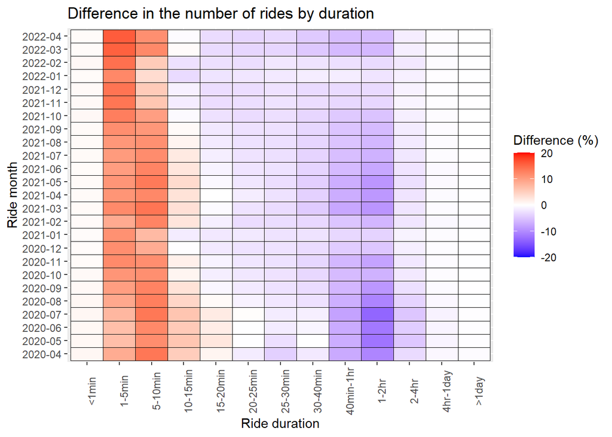

```r
hp_count <- ggplot(df_data, aes(duration_bin, ride_month,
                                fill=difference_count)) +
  geom_tile(color='black') +
  scale_fill_gradient2(low="blue", mid='white', high="red",
                       limit=c(-20,20),
                       name='Difference (%)') +
  labs(x='Ride duration', y='Ride month', title='Difference in the number of rides by duration') +
  theme(axis.text.x = element_text(angle = 90))
ggsave('Plots/Ride_Time.png', plot = hp_count)
hp_count
```

We see a very strong pattern that is consistent over all months; casual users take longer rides than members. About two years ago, the cutoff was around the 20 minute mark; both members and casual users took ~20 minute long rides at the same rates. Since then, this has shrunk, and now the cutoff is around the 10 minute mark.

# 3. Explore Bike Type

Next we see if there is a difference in the type of bikes between members and casual users

```r
# Get counts by months for each bike type used for each user type
df_data <- df %>%
  group_by(member_casual, ride_month, rideable_type) %>%
  summarize(ride_count=n())
df_total <- df_data %>%
  group_by(member_casual, ride_month) %>%
  summarize(total_count=sum(ride_count))
df_data <- merge(x=df_data, y=df_total,
                    by=c("member_casual", "ride_month"), all=TRUE) %>%
  mutate(percent_count = ride_count / total_count * 100)
```

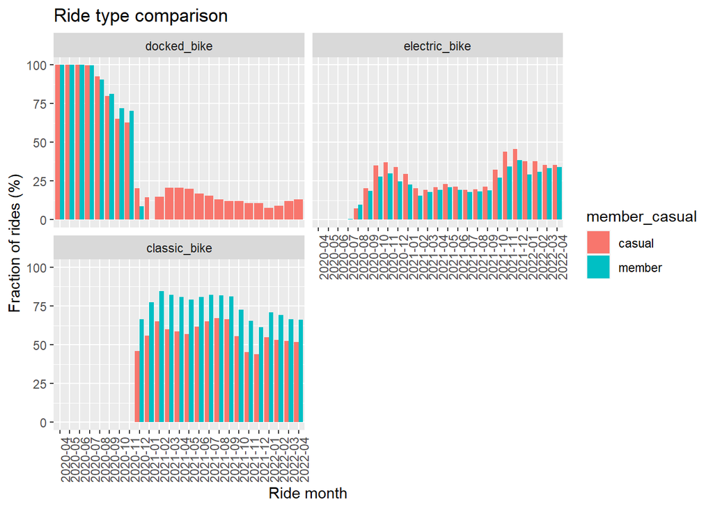

```r
bp_bike <- ggplot(data=df_data, aes(x=ride_month, y=percent_count, fill=member_casual)) +
  geom_bar(stat='identity', position=position_dodge()) +
  facet_wrap(~rideable_type, ncol=2) +
  labs(x='Ride month', y='Fraction of rides (%)', title='Ride type comparison') +
  theme(axis.text.x = element_text(angle = 90))
ggsave('Plots/Bike_Type.png', plot=bp_bike)
bp_bike
```

Given the drastic and sudden drop, this could be representative of a significant difference between the two user groups, or it might be a technical artifact from how record keeping is handled.

# 4. Temporal Differences

Next, we need to see if there are any differences in the time of day, day of the week, or seasonal differences between casual users and members.

## Time of Day

First, we see if bike usage depends on time of day, and if so, whether there are any differences in when members and casual users prefer to ride their bikes.

To do this, we make 2 plots. First, we do a heatmap of time of day versus month to see if there are any seasonal changes or patterns, and then we do a bar graph for the past last month, so that we can compare the two data side by side to see if there are any differences by user type.

```r
# we group data by month, hour, and user type
df_data <- df %>%
  mutate(ride_time = hour(hms(ride_time))) %>%
  group_by(member_casual, ride_month, ride_time) %>%
  summarize(ride_count=n())
# next we get the total counts
df_total <- df_data %>%
  group_by(member_casual, ride_month) %>%
  summarize(total_count=sum(ride_count))
df_data <- merge(x=df_data, y=df_total,
                    by=c("member_casual", "ride_month"), all=TRUE) %>%
  mutate(percent_count = ride_count / total_count * 100)
```

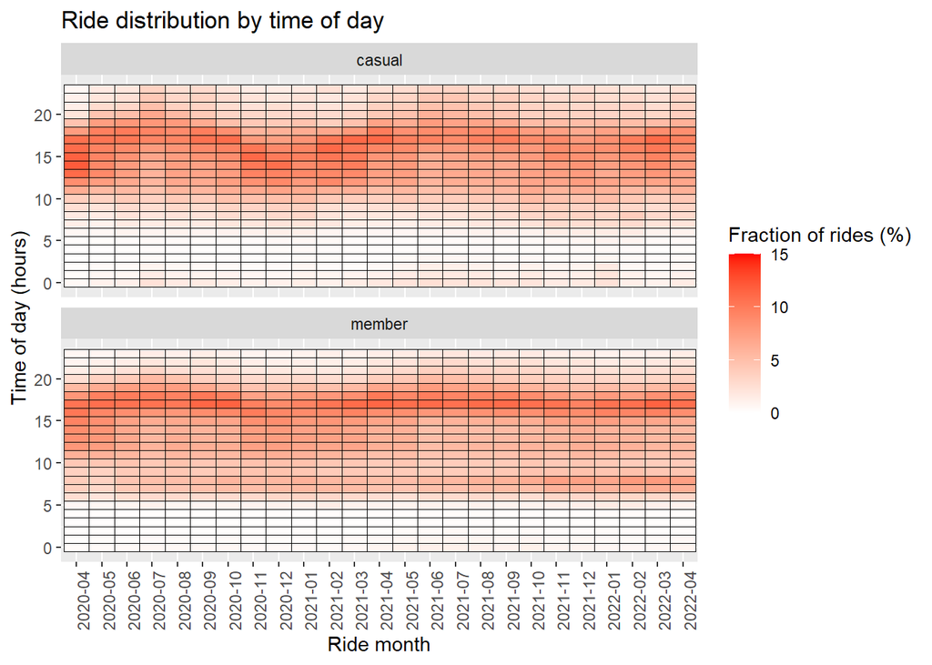

```r
hp_hour <- ggplot(df_data, aes(x=ride_month, y=ride_time, fill=percent_count)) +
  geom_tile(color='black') +
  scale_fill_gradient(low="white", high="red",
                       limit=c(0,15),
                       name='Fraction of rides (%)') +
  labs(x='Ride month', y='Time of day (hours)',
       title='Ride distribution by time of day') +
  facet_wrap(~member_casual, ncol=1) +
  theme(axis.text.x = element_text(angle = 90))
ggsave('Plots/Monthly_Hour.png', plot=hp_hour)
hp_hour
```

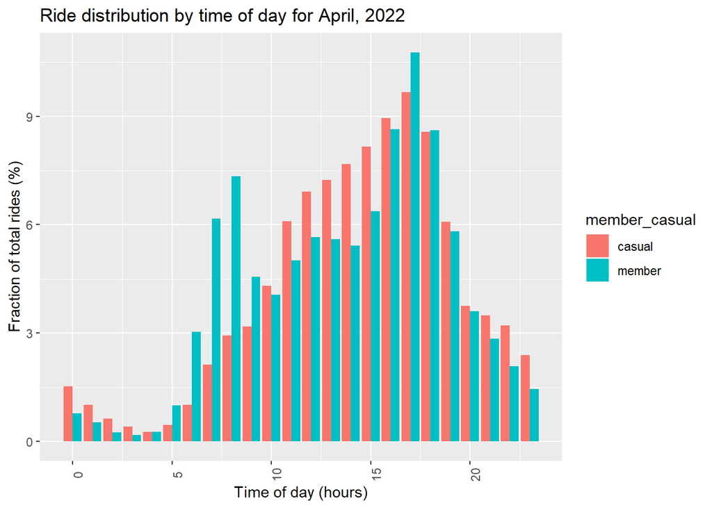

```r
df_plot <- df_data %>%
  filter(ride_month == '2022-04')
bp_hour <- ggplot(df_plot, aes(x=ride_time, y=percent_count,
                               fill=member_casual)) +
  geom_bar(stat='identity', position=position_dodge()) +
  labs(x='Time of day (hours)', y='Fraction of total rides (%)',
       title='Ride distribution by time of day for April, 2022') +
  theme(axis.text.x = element_text(angle = 90))
ggsave('Plots/Hour_Dist.png', plot=bp_hour)
bp_hour
```

While there appears to be a slight shift in the hour of day use over time, the fluctuation is small. It appears to be seasonal - in July of 2 years casual users ended up having peak activity a few hours later than in December - but does not seem useful for answering the key question. Similarly, while there is a difference in the hourly use habits of members and casual users - there is a spike in member usage between 7 and 9 am that isn’t present for casual users - it doesn’t correspond to a unique habit on the part of casual users that can be targeted. Perhaps an ad campaign to convince more people of the validity of biking to work may be applicable here, but otherwise this data isn’t applicable to the key question.

## Time of the Week

Next, we plot usage by day of the week versus month. As we are also interested in seasonal changes, we do not take percentages, but use absolute counts this time.

```r
# get total ride counts by data and member type
df_data <- df %>%
  group_by(member_casual, ride_date) %>%
  summarize(ride_count=n()) %>%
  mutate(ride_date = strptime(ride_date, "%Y-%m-%d")) %>%
  mutate(ride_month = format(ride_date, "%Y-%m"),
         ride_day = wday(ride_date, label=TRUE)) %>%
  group_by(member_casual, ride_month, ride_day) %>%
  summarize(average_count=mean(ride_count))
max(df_data$average_count)
```

```
## [1] 17971
```

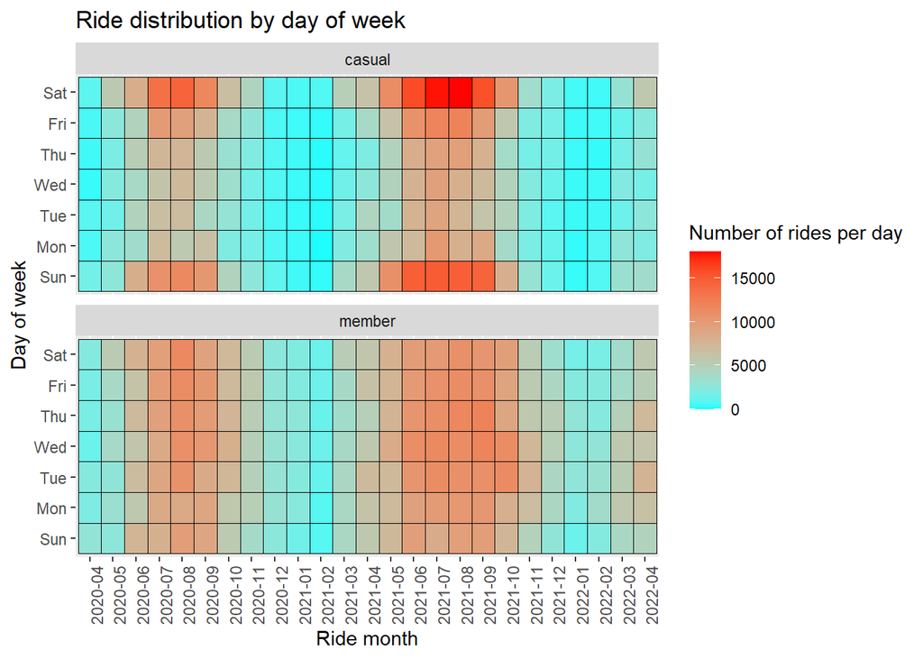

```r
hp_day <- ggplot(df_data, aes(x=ride_month, y=ride_day,
                              fill=average_count)) +
  geom_tile(color='black') +
  scale_fill_gradient(low="cyan", high="red",
                       limit=c(0,18000),
                       name='Number of rides per day') +
  labs(x='Ride month', y='Day of week',
       title='Ride distribution by day of week') +
  facet_wrap(~member_casual, ncol=1) +
  theme(axis.text.x = element_text(angle = 90))
ggsave('Plots/Monthly_Day.png', plot=hp_day)
hp_day
```

Here, we note 2 more key factors:

- There is a seasonal effect, where people - both members and casual users - will use the services more during the summer months. While this can’t be used to target casual users, it can be kept in mind as the winters are lean months for Cyclic where advertising would have minimal effect.
- Casual users are more likely to bike on the weekends, while members will bike more evenly across the entire week.

The second is a fairly notable difference that could be targeted; either to try and convert casual users into daily users, or to highlight the convenience of weekend biking.

# 5. Key Stations

## Compare by Station Name

```r
df_data <- df %>%
  group_by(member_casual, ride_month, start_station_name) %>%
  summarize(ride_count=n())
df_total <- df_data %>%
  group_by(member_casual, ride_month) %>%
  summarize(total_count=sum(ride_count))
```

```r
df_data <- merge(x=df_data, y=df_total,
                    by=c("member_casual", "ride_month"), all=TRUE) %>%
  mutate(percent_count = ride_count / total_count * 100)

# get difference in rate by month and station
df_member <- df_data %>%
  filter(member_casual=='member') %>%
  mutate(member_count=percent_count
         ) %>%
  select(ride_month, start_station_name, member_count)
df_casual <- df_data %>%
  filter(member_casual=='casual') %>%
  mutate(casual_count=percent_count
         ) %>%
  select(ride_month, start_station_name, casual_count)

df_compare <- merge(x=df_member, y=df_casual,
                 by=c('ride_month', 'start_station_name'), all=TRUE) %>%
  replace(is.na(.), 0)
df_compare$difference_count <- df_compare$member_count - df_compare$casual_count

# find top 6 stations with biggest differences
df_diff <- df_compare %>%
  group_by(start_station_name) %>%
  summarize(top_member=max(difference_count),
            top_casual=min(difference_count)
            )
stations <- c(df_diff %>%
                arrange(desc(top_member)) %>%
                head(n=3) %>%
                pull(start_station_name),
              df_diff %>%
                arrange(top_casual) %>%
                head(n=3) %>%
                pull(start_station_name)
              )
df_plot <- df_data %>%
  filter(start_station_name %in% stations)
```

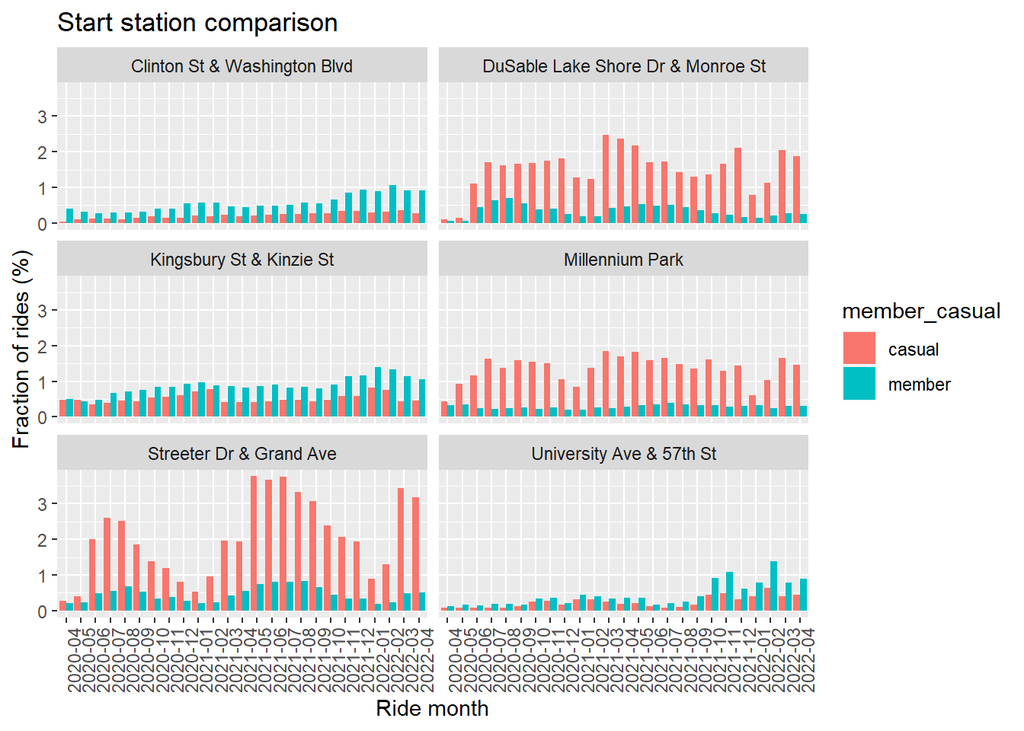

```r
bp_station <- ggplot(data=df_plot, aes(x=ride_month, y=percent_count,
                                       fill=member_casual)) +
  geom_bar(stat='identity', position=position_dodge()) +
  facet_wrap(~start_station_name, ncol=2) +
  labs(x='Ride month', y='Fraction of rides (%)', title='Start station comparison') +
  theme(axis.text.x = element_text(angle = 90))
ggsave('Plots/Start_Station.png')
bp_station
```

## Compare by Station Id

```r
df_data <- df %>%
  group_by(member_casual, ride_month, start_station_id) %>%
  summarize(ride_count=n())
df_total <- df_data %>%
  group_by(member_casual, ride_month) %>%
  summarize(total_count=sum(ride_count))
```

```r
df_data <- merge(x=df_data, y=df_total,
                    by=c("member_casual", "ride_month"), all=TRUE) %>%
  mutate(percent_count = ride_count / total_count * 100)

# get difference in rate by month and station
df_member <- df_data %>%
  filter(member_casual=='member') %>%
  mutate(member_count=percent_count
         ) %>%
  select(ride_month, start_station_id, member_count)
df_casual <- df_data %>%
  filter(member_casual=='casual') %>%
  mutate(casual_count=percent_count
         ) %>%
  select(ride_month, start_station_id, casual_count)

df_compare <- merge(x=df_member, y=df_casual,
                 by=c('ride_month', 'start_station_id'), all=TRUE) %>%
  replace(is.na(.), 0)
df_compare$difference_count <- df_compare$member_count - df_compare$casual_count

# find top 6 stations with biggest differences
df_diff <- df_compare %>%
  group_by(start_station_id) %>%
  summarize(top_member=max(difference_count),
            top_casual=min(difference_count)
            )
stations <- c(df_diff %>%
                arrange(desc(top_member)) %>%
                head(n=3) %>%
                pull(start_station_id),
              df_diff %>%
                arrange(top_casual) %>%
                head(n=3) %>%
                pull(start_station_id)
              )
df_plot <- df_data %>%
  filter(start_station_id %in% stations)
```

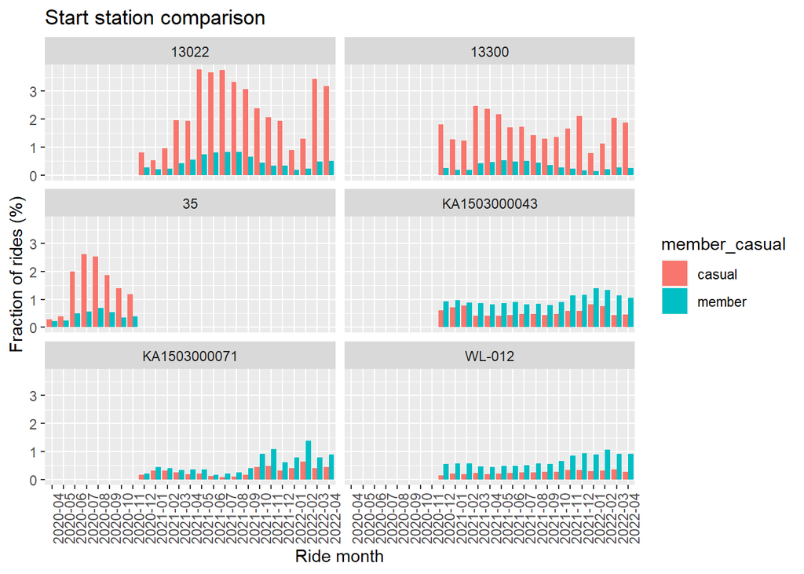

```r
ggplot(data=df_plot, aes(x=ride_month, y=percent_count, fill=member_casual)) +
  geom_bar(stat='identity', position=position_dodge()) +
  facet_wrap(~start_station_id, ncol=2) +
  labs(x='Ride month', y='Fraction of rides (%)', title='Start station comparison') +
  theme(axis.text.x = element_text(angle = 90))
```

Looking at the results for station_id, it appears to be a case where station ids were changed around November of 2020. ids *35* and *13022* line up with *Streeter Dr & Grand Ave*, while *13300* lines up with *DuSable Lake Shore Dr & Monroe St*. Therefore, we can conclude that using station id instead of station name doesn’t provide us with extra information in this case, and therefore we should stick to using station names for our analysis.

## Compare End Stations

We can run the analysis on end station names, to see if there are any patterns for where people finish their trips

```r
df_data <- df %>%
  group_by(member_casual, ride_month, end_station_name) %>%
  summarize(ride_count=n())
df_total <- df_data %>%
  group_by(member_casual, ride_month) %>%
  summarize(total_count=sum(ride_count))
```

```r
df_data <- merge(x=df_data, y=df_total,
                    by=c("member_casual", "ride_month"), all=TRUE) %>%
  mutate(percent_count = ride_count / total_count * 100)

# get difference in rate by month and station
df_member <- df_data %>%
  filter(member_casual=='member') %>%
  mutate(member_count=percent_count
         ) %>%
  select(ride_month, end_station_name, member_count)
df_casual <- df_data %>%
  filter(member_casual=='casual') %>%
  mutate(casual_count=percent_count
         ) %>%
  select(ride_month, end_station_name, casual_count)

df_compare <- merge(x=df_member, y=df_casual,
                 by=c('ride_month', 'end_station_name'), all=TRUE) %>%
  replace(is.na(.), 0)
df_compare$difference_count <- df_compare$member_count - df_compare$casual_count

# find top 6 stations with biggest differences
df_diff <- df_compare %>%
  group_by(end_station_name) %>%
  summarize(top_member=max(difference_count),
            top_casual=min(difference_count)
            )
stations <- c(df_diff %>%
                arrange(desc(top_member)) %>%
                head(n=3) %>%
                pull(end_station_name),
              df_diff %>%
                arrange(top_casual) %>%
                head(n=3) %>%
                pull(end_station_name)
              )
df_plot <- df_data %>%
  filter(end_station_name %in% stations)
```

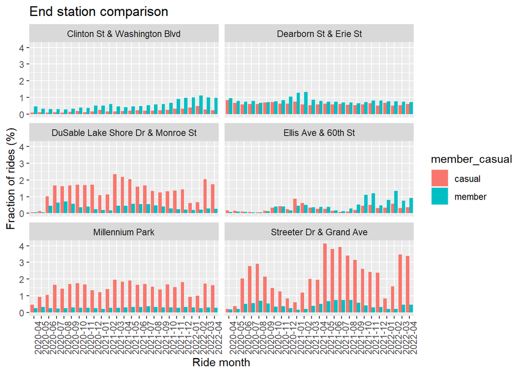

```r
ggplot(data=df_plot, aes(x=ride_month, y=percent_count, fill=member_casual)) +
  geom_bar(stat='identity', position=position_dodge()) +
  facet_wrap(~end_station_name, ncol=2) +
  labs(x='Ride month', y='Fraction of rides (%)', title='End station comparison') +
  theme(axis.text.x = element_text(angle = 90))
```

Here we notice that the top streets where casual users end their rides are the same as where they started their rides.

## Top Station Ride Times

To see if there is a connection, we look, for the top 3 stations where casual users are over represented, if there are any patterns in the start ride times for rides that start or end at those stations. To not over complicate the data with too many dimensions, and to use recent data, we restrict ourselves to data from the last 2 months.

```r
# first we get a vector of target stations
stations <- df_diff %>%
            arrange(top_casual) %>%
            head(n=3) %>%
            pull(end_station_name)

# next, we get data for the last 2 months for those stations
df_total <- df %>%
  filter(ride_month %in% c('2022-03', '2022-04'),
         (start_station_name %in% stations |
            end_station_name %in% stations)
         ) %>%
  mutate(ride_time = hour(hms(ride_time))) %>%
  select(member_casual, start_station_name, end_station_name,
         ride_time)
df_start <- df_total %>%
  filter(start_station_name %in% stations) %>%
  mutate(station=start_station_name, direction='start') %>%
  select(member_casual, station, direction, ride_time)
df_end <- df_total %>%
  filter(end_station_name %in% stations) %>%
  mutate(station=end_station_name, direction='end') %>%
  select(member_casual, station, direction, ride_time)
df_data <- rbind(df_start, df_end) %>%
  group_by(member_casual, station, direction, ride_time) %>%
  summarize(ride_count=n())
```

```
## You can override using the `.groups` argument.
```

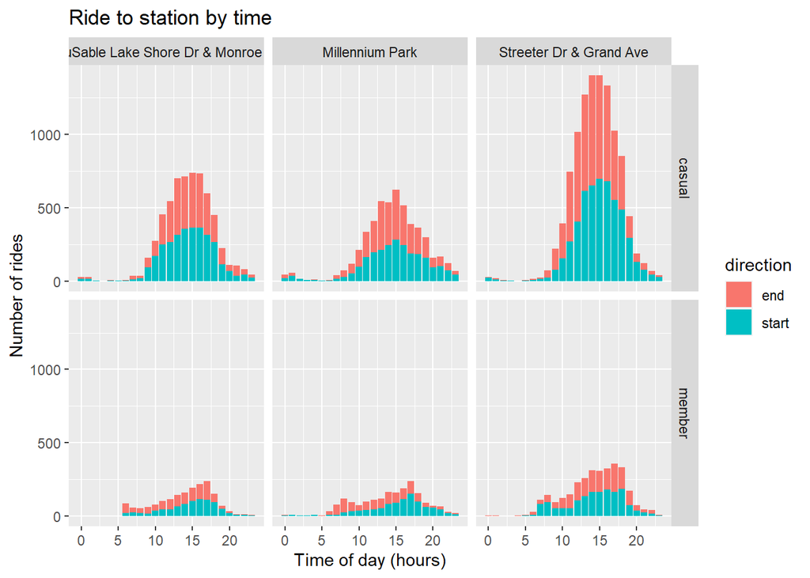

```r
ggplot(data=df_data, aes(x=ride_time, y=ride_count, fill=direction)) +
  geom_bar(stat='identity') +
  facet_grid(member_casual~station) +
  labs(x = "Time of day (hours)", y="Number of rides", title='Ride to station by time')
```

We can see here that the most frequent rides both to and from the stations occur at around the street times. Therefore, while we can note that usage at these stations is highest around 3pm, we can’t use this data to derive any more interesting conclusions regarding trends of casual users, such as we might have had if, say, there was a high uptick of rides to the stations in the morning, and another uptick in rides away from the stations in the evening, indicating people using the bikes for work.